# 考研初试应考时间

2017年，十二月27日

## 一、清醒时间安排情况

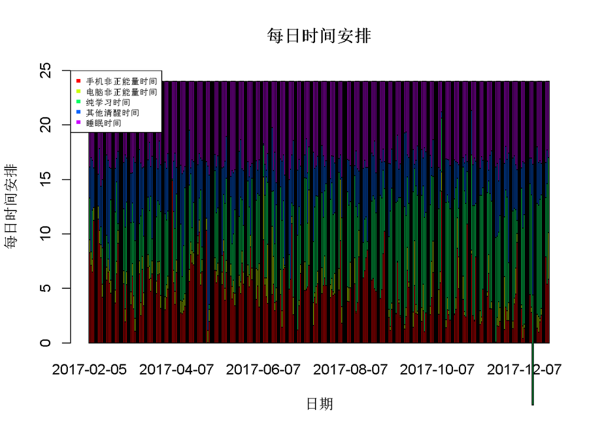

图中反映了本期323天每日时间的构成及其变化，

启动时间，反映了本人自起床开始到做本日第一件事，平均要花1.46小时，占全部清醒时间的8.71%；

纯学习时间，平均为6.48小时，占清醒时间比重为38.66%；

手机非正能量时间每天为5小时,占清醒时间比重为29.81%；

电脑非正能量时间平均每天为1.12小时,占清醒时间比重为6.71%。

## 二、睡眠状况

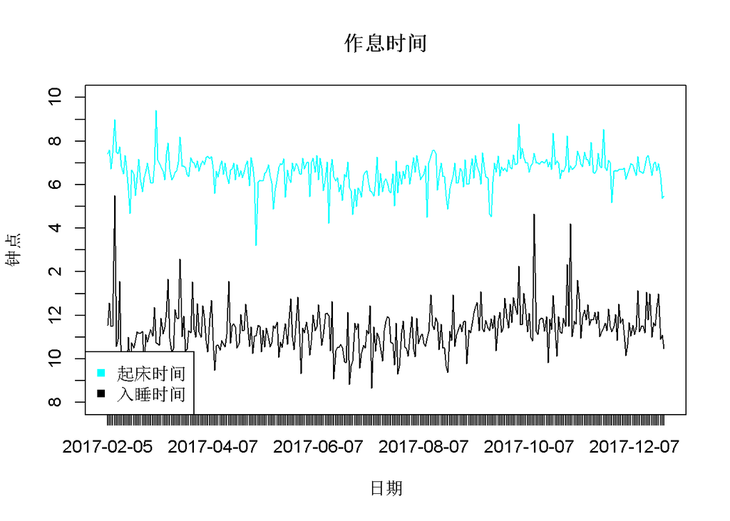

“作息时间”图反映了本期本人每日的入睡与起床时间，在这一期间，本人平均每天11点21分入睡，6点37分起床，睡眠时间平均为7.24小时；

入睡时间和起床时间有显著的相关关系，相较而言，起床时间的波动要比入睡时间更小。

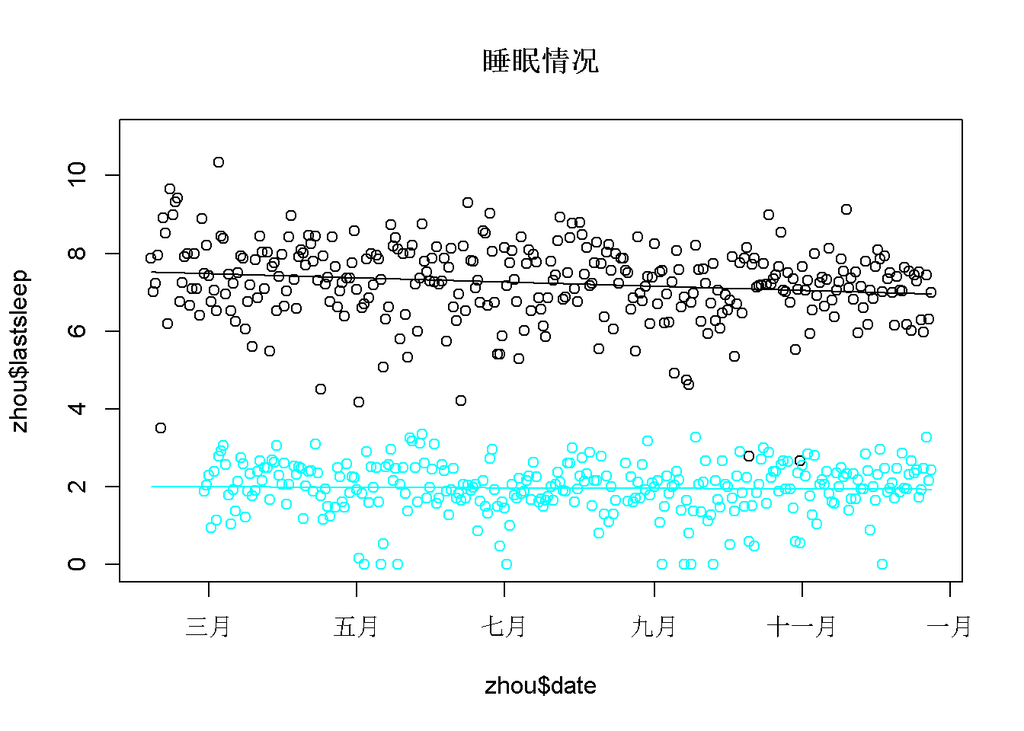

从线性趋势上看，总睡眠时间趋向显著减少，深睡眠时间无明显变化，睡眠质量向好发展。

## 三、学习状况

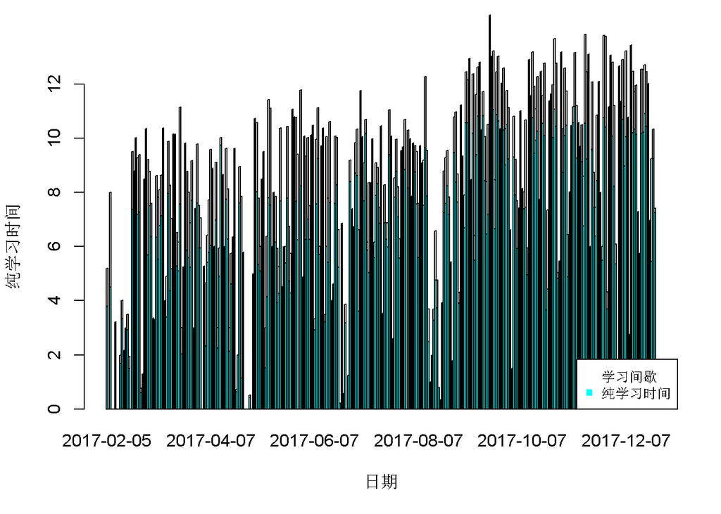

本期平均每日毛学习/工作时间为8.08小时，呈显著增加趋势；

纯学习/工作时间为6.48小时，呈显著增加趋势，用于学习的时间达到了平均水平；

时间利用比为1.25，学习状态良好。

### 核心学习时间

核心学习时间指的是完全由自主学习构成，推动复习进度的时间；本期平均每周的核心学习时间为29.61小时，占纯学习时间的66.25%；

就今年而言，本期用于核心学习的时间达到了平均水平。

### 数学

本期平均每周用于考研数学自主学习的时间为9.45小时，占纯学习时间的21.15%；

就今年而言，本期用于考研数学的时间达到了平均水平。

### 专业课

本期平均每周用于专业课学习的时间为5.32小时，占纯学习时间的11.91%；

就今年而言，本期用于专业课学习的时间达到了平均水平。

### 英语

本期平均每周用于英语学习的时间为6.58小时，占纯学习时间的14.72%；

就今年而言，本期用于英语学习的时间达到了平均水平。

### 单词

本期平均每周用于单词学习的时间为4.07小时，占纯学习时间的9.11%；

就今年而言，本期用于单词学习的时间值得肯定。

### 政治

本期平均每周用于政治学习的时间为4.19小时，占纯学习时间的9.37%；

就今年而言，本期用于政治学习的时间达到了平均水平。

## 四、娱乐时间

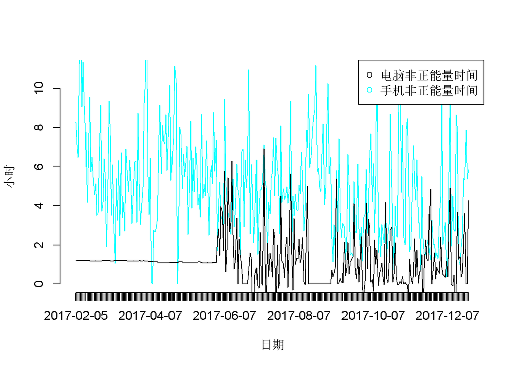

平均每日使用手机时间为5.79小时，本期内趋向显著减少；其中非正能量时间5小时，本期内趋向显著减少，与纯学习时间 有显著的相关关系。

平均每日使用电脑时间为2.19小时；其中非正能量时间为1.12小时，本期内趋向显著减少，与纯学习时间 有显著的相关关系。

两者之和 与纯学习时间 有显著的相关关系。